# ENTREGA FINAL

## GeoDataFrame

```python
from  fiona import listlayers
import os

russiaMaps=os.path.join('maps','russiaMaps_5940_all.gpkg')

#layers in maps
listlayers(russiaMaps)
```

```
['airports',
 'states',
 'municipalities',
 'country',
 'cities',
 'rivers',
 'border']
```

```python
# reading in the data:
import os
import geopandas as gpd

states=gpd.read_file(russiaMaps,layer='states')
municipalities=gpd.read_file(russiaMaps,layer='municipalities')
airports=gpd.read_file(russiaMaps,layer='airports')
rivers=gpd.read_file(russiaMaps,layer='rivers')
border=gpd.read_file(russiaMaps,layer='border')
```

```python
import pandas as pd


portsFile=os.path.join('data','UpdatedPub150.csv')

infoseaports=pd.read_csv(portsFile)

infoseaports.columns.to_list()
```

```
['World Port Index Number',
 'Region Name',
 'Main Port Name',
 'Alternate Port Name',
 'UN/LOCODE',
 'Country Code',
 'World Water Body',
 'IHO S-130 Sea Area',
 'Sailing Direction or Publication',
 'Publication Link',
 'Standard Nautical Chart',
 'IHO S-57 Electronic Navigational Chart',
 'IHO S-101 Electronic Navigational Chart',
 'Digital Nautical Chart',
 'Tidal Range (m)',
 'Entrance Width (m)',
 'Channel Depth (m)',
 'Anchorage Depth (m)',
 'Cargo Pier Depth (m)',
 'Oil Terminal Depth (m)',
 'Liquified Natural Gas Terminal Depth (m)',
 'Maximum Vessel Length (m)',
 'Maximum Vessel Beam (m)',
 'Maximum Vessel Draft (m)',
 'Offshore Maximum Vessel Length (m)',
 'Offshore Maximum Vessel Beam (m)',
 'Offshore Maximum Vessel Draft (m)',
 'Harbor Size',
 'Harbor Type',
 'Harbor Use',
 'Shelter Afforded',
 'Entrance Restriction - Tide',
 'Entrance Restriction - Heavy Swell',
 'Entrance Restriction - Ice',
 'Entrance Restriction - Other',
 'Overhead Limits',
 'Underkeel Clearance Management System',
 'Good Holding Ground',
 'Turning Area',
 'Port Security',
```

[output cut: 53 more lines]

```
 'Services - Electrical Repair',
 'Services - Ice Breaking',
 'Services - Diving',
 'Supplies - Provisions',
 'Supplies - Potable Water',
 'Supplies - Fuel Oil',
 'Supplies - Diesel Oil',
 'Supplies - Aviation Fuel',
 'Supplies - Deck',
 'Supplies - Engine',
 'Repairs',
 'Dry Dock',
 'Railway',
 'Latitude',
 'Longitude']
```

```python
infoseaports.rename(columns={'Main Port Name':'portName'},inplace=True)

infoseaports=infoseaports.loc[:,['portName', 'Country Code','Latitude', 'Longitude']]

infoseaports.info()
```

```
<class 'pandas.core.frame.DataFrame'>
RangeIndex: 3739 entries, 0 to 3738
Data columns (total 4 columns):
 #   Column        Non-Null Count  Dtype
---  ------        --------------  -----
 0   portName      3739 non-null   object
 1   Country Code  3739 non-null   object
 2   Latitude      3739 non-null   float64
 3   Longitude     3739 non-null   float64
dtypes: float64(2), object(2)
memory usage: 117.0+ KB
```

```python
#SIEMPRE QUE HAY LATITUD/lONGITUD EL TIPO DE CRS ES NO PROYECTADO
infoseaports.head()
```

|  | portName | Country Code | Latitude | Longitude |
| --- | --- | --- | --- | --- |
| 0 | Maurer | United States | 40.533333 | -74.250000 |
| 1 | Mangkasa Oil Terminal | Indonesia | -2.733333 | 121.066667 |
| 2 | Iharana | Madagascar | -13.350000 | 50.000000 |
| 3 | Andoany | Madagascar | -13.400000 | 48.300000 |
| 4 | Chake Chake | Tanzania | -5.250000 | 39.766667 |

```python
#el crs NO PROYECTADO es el 4326
seaports=gpd.GeoDataFrame(data=infoseaports.copy(),
                           geometry=gpd.points_from_xy(infoseaports.Longitude,
                                                       infoseaports.Latitude),
                          crs=4326)


seaports_russ=seaports[seaports['Country Code']=='Russia'].copy()


seaports_russ.reset_index(drop=True, inplace=True)


seaports_russ_5940=seaports_russ.to_crs(5940)
```

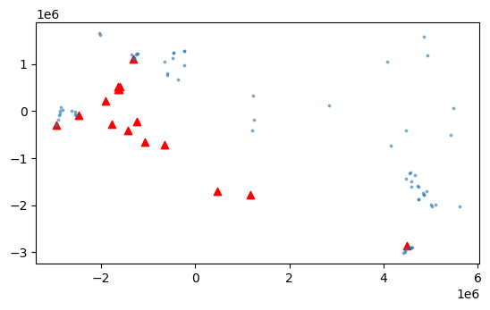

```python
largeAirports=airports[airports['kind']=='large_airport']
largeAirports.reset_index(drop=True, inplace=True)


base=largeAirports.plot(color='red',marker="^")
seaports_russ_5940.plot(ax=base,alpha=0.5,markersize=3)
```

# EJERCICIO 01:

## Distance between points

1. Use two maps of points.
2. Compute the distance matrix for both maps.
3. Select one row of the distance matrix, and plot the two points with the minimal distance on top of the country of your choosing.

```python
seaports_russ_5940.head()
```

|  | portName | Country Code | Latitude | Longitude | geometry |
| --- | --- | --- | --- | --- | --- |
| 0 | Bukhta Gaydamak | Russia | 42.866667 | 132.683333 | POINT (4572656.440 -2903653.774) |
| 1 | Adler | Russia | 43.433333 | 39.933333 | POINT (-2954064.563 -303104.287) |
| 2 | Vitaz Marine Terminal | Russia | 52.700000 | 143.550000 | POINT (4672279.177 -1353504.256) |
| 3 | Shakotan | Russia | 43.866667 | 146.833333 | POINT (5606042.767 -2028420.271) |
| 4 | Azov | Russia | 47.100000 | 39.433333 | POINT (-2542815.985 -63900.270) |

```python
largeAirports.head()
```

|  | name | kind | latitude_deg | longitude_deg | elevation_ft | region_name | municipality | geometry |
| --- | --- | --- | --- | --- | --- | --- | --- | --- |
| 0 | Sheremetyevo International Airport | large_airport | 55.972599 | 37.414600 | 622.0 | Moscow Oblast | Moscow | POINT (-1594689.376 517304.239) |
| 1 | Domodedovo International Airport | large_airport | 55.408798 | 37.906300 | 588.0 | Moscow Oblast | Moscow | POINT (-1644777.787 459913.318) |
| 2 | Pulkovo Airport | large_airport | 59.800301 | 30.262501 | 78.0 | Saint Petersburg (city) | St. Petersburg | POINT (-1308631.240 1097188.014) |
| 3 | Vnukovo International Airport | large_airport | 55.591499 | 37.261501 | 685.0 | Moscow Oblast | Moscow | POINT (-1641365.027 509424.872) |
| 4 | Novosibirsk Tolmachevo Airport | large_airport | 55.019756 | 82.618675 | 365.0 | Novosibirsk Oblast | Novosibirsk | POINT (475373.773 -1702445.286) |

```python
seaports_russ_5940.set_index('portName').geometry.apply\
(lambda g: largeAirports.set_index('name').geometry.distance(g)/1000).\
sort_index(axis=0).sort_index(axis=1)
```

| name portName | Domodedovo International Airport | Gagarin International Airport | Kazan International Airport | Koltsovo Airport | Krasnoyarsk International Airport | Kurumoch International Airport | Lipetsk Air Base | Novosibirsk Tolmachevo Airport | Platov International Airport | Pulkovo Airport | Sheremetyevo International Airport | Sochi International Airport | Ufa International Airport | Vladivostok International Airport | Vnukovo International Airport | Zhukovsky International Airport |
| --- | --- | --- | --- | --- | --- | --- | --- | --- | --- | --- | --- | --- | --- | --- | --- | --- |
| Adler | 1515.396887 | 1180.950056 | 1706.591112 | 2345.711677 | 4371.551421 | 1533.389250 | 1167.951244 | 3703.944186 | 523.738573 | 2160.617816 | 1587.756608 | 3.101497 | 1916.810380 | 7877.571497 | 1543.821138 | 1530.801516 |
| Aleksandrovsk -Sakhalinskiy | 6691.636239 | 6627.905858 | 6130.487328 | 5439.876128 | 3564.349331 | 6260.625062 | 6878.766875 | 4249.074676 | 7360.104742 | 6605.808855 | 6661.973711 | 7782.292068 | 5868.977731 | 1289.738120 | 6703.775293 | 6667.388825 |
| Anapa | 1318.552050 | 1140.976305 | 1643.459045 | 2346.191521 | 4412.947392 | 1511.453268 | 994.337498 | 3760.772230 | 407.680442 | 1917.704366 | 1386.068644 | 309.750749 | 1923.882091 | 7910.687191 | 1339.886457 | 1336.891346 |
| Arkhangels'k | 1094.244533 | 1576.097030 | 1177.216855 | 1484.004464 | 3083.469973 | 1439.114772 | 1424.121749 | 2686.055694 | 2066.446524 | 790.204940 | 1031.088667 | 2587.938816 | 1497.168824 | 6248.891451 | 1078.306320 | 1074.893138 |
| Azov | 1039.640938 | 799.993909 | 1301.874666 | 2007.538429 | 4080.857544 | 1171.330302 | 693.652345 | 3434.282921 | 65.800615 | 1694.502283 | 1112.089361 | 473.806138 | 1587.582409 | 7575.061190 | 1068.323709 | 1055.090834 |
| ... | ... | ... | ... | ... | ... | ... | ... | ... | ... | ... | ... | ... | ... | ... | ... | ... |
| Vladivostok | 6999.656683 | 6792.255790 | 6341.142857 | 5583.091564 | 3516.113071 | 6420.429139 | 7126.412978 | 4192.444401 | 7521.680491 | 7048.810242 | 6983.788294 | 7884.393811 | 5999.488591 | 45.128432 | 7020.650563 | 6975.619238 |
| Vostochnyy | 7103.230129 | 6902.482135 | 6448.889369 | 5693.041546 | 3630.154818 | 6530.534548 | 7233.111817 | 4308.201978 | 7632.549859 | 7144.820536 | 7086.624433 | 7997.869928 | 6110.441544 | 123.599219 | 7123.780028 | 7079.160352 |
| Vyborg | 859.748673 | 1590.452337 | 1425.913484 | 2016.906049 | 3821.806027 | 1635.371281 | 1202.670123 | 3373.440149 | 1800.475803 | 140.492669 | 785.382400 | 2296.022341 | 1874.237131 | 7024.561981 | 815.125870 | 856.526492 |
| Yeysk | 1080.059646 | 902.539778 | 1395.516513 | 2111.796747 | 4188.512662 | 1274.598403 | 746.625225 | 3543.788659 | 173.893413 | 1708.416172 | 1149.912795 | 451.880086 | 1693.813046 | 7680.813842 | 1104.624339 | 1097.264963 |
| Zarubino | 7007.392272 | 6789.535502 | 6342.642691 | 5581.098930 | 3507.329552 | 6417.984948 | 7129.432419 | 4179.730808 | 7517.723318 | 7066.657674 | 6992.584398 | 7875.558146 | 5995.645671 | 143.324823 | 7029.021639 | 6983.405700 |

67 rows × 16 columns

```python
#Guardo el codigo
distanceMatrixKM_sea_air= seaports_russ_5940.set_index('portName').geometry.apply\
                          (lambda g: largeAirports.set_index('name').geometry.distance(g)/1000).\
                          sort_index(axis=0).sort_index(axis=1)
```

```python
SomeStats=pd.DataFrame()
SomeStats['min1'] = distanceMatrixKM_sea_air.apply(lambda row: row.nsmallest(1).values[0], axis=1)
SomeStats['min2'] = distanceMatrixKM_sea_air.apply(lambda row: row.nsmallest(2).values[-1], axis=1)

SomeStats.head(1)
```

| portName | min1 | min2 |
| --- | --- | --- |
| Adler | 3.101497 | 523.738573 |

# EJERCICIO 02

## Distance between line and point

1. Use a map of points and a map of lines.
2. Compute the distance matrix for both maps.
3. Select one line of the distance matrix, and plot the closests and the farthest point to that line.

```python
#Agrego el segundo mapa (rivers), el primer mapa sera largeAirports
rivers
```

|  | NAME | SYSTEM | geometry |
| --- | --- | --- | --- |
| 0 | Amur | NaN | MULTILINESTRING ((3057370.355 -2549290.041, 30... |
| 1 | Aldan | Lena | LINESTRING (3246715.035 -1619331.482, 3192467.... |
| 2 | Kolyma | NaN | LINESTRING (3949007.836 688333.806, 3991444.15... |
| 3 | Angara | NaN | MULTILINESTRING ((2005998.009 -2383015.585, 19... |
| 4 | Irtysh | Ob | LINESTRING (-52594.773 -1593373.690, -47674.25... |
| 5 | Ob | Ob | MULTILINESTRING ((83734.271 -644406.441, 63598... |
| 6 | Yenisey | NaN | MULTILINESTRING ((1546238.603 -2279212.961, 14... |
| 7 | Lena | Lena | MULTILINESTRING ((3243504.624 -717142.384, 319... |
| 8 | Vilyuy | Lena | LINESTRING (3062114.417 -678286.603, 3067596.5... |
| 9 | Tobol | Ob | LINESTRING (-673929.518 -1093286.336, -667346.... |
| 10 | Ural | NaN | MULTILINESTRING ((-1518901.800 -700941.771, -1... |
| 11 | Kama | NaN | LINESTRING (-809826.225 -273358.004, -792864.0... |
| 12 | Don | NaN | LINESTRING (-2535870.451 -62651.357, -2486638.... |
| 13 | Volga | NaN | LINESTRING (-1548466.682 860132.421, -1580962.... |
| 14 | Pechora | NaN | LINESTRING (-232660.521 -205687.752, -258044.0... |
| 15 | Dnieper | NaN | LINESTRING (-1682175.445 736027.591, -1694440.... |
| 16 | Suir | NaN | MULTILINESTRING ((-1079430.779 876672.449, -10... |
| 17 | Neva | NaN | MULTILINESTRING ((-1268739.772 1046868.488, -1... |

```python
#Creo la matriz de distancias para ambos mapas
distanceMatrixKM_riv_air=rivers.set_index('NAME').geometry.apply\
(lambda g: largeAirports.set_index('name').geometry.distance(g)/1000).\
sort_index(axis=0).sort_index(axis=1)
distanceMatrixKM_riv_air
```

| name NAME | Domodedovo International Airport | Gagarin International Airport | Kazan International Airport | Koltsovo Airport | Krasnoyarsk International Airport | Kurumoch International Airport | Lipetsk Air Base | Novosibirsk Tolmachevo Airport | Platov International Airport | Pulkovo Airport | Sheremetyevo International Airport | Sochi International Airport | Ufa International Airport | Vladivostok International Airport | Vnukovo International Airport | Zhukovsky International Airport |
| --- | --- | --- | --- | --- | --- | --- | --- | --- | --- | --- | --- | --- | --- | --- | --- | --- |
| Aldan | 5027.998116 | 5035.582733 | 4521.215912 | 3888.328216 | 2035.497334 | 4678.017760 | 5239.325776 | 2714.557863 | 5758.133179 | 4900.381181 | 4993.193331 | 6208.416373 | 4314.150769 | 1764.007075 | 5036.508587 | 5003.912994 |
| Amur | 5431.181496 | 5251.089026 | 4786.906715 | 4042.003349 | 2012.928145 | 4878.976049 | 5567.274191 | 2702.477892 | 5983.865593 | 5475.414854 | 5413.813421 | 6364.114588 | 4464.454708 | 565.118977 | 5451.239297 | 5407.075949 |
| Angara | 3530.663620 | 3285.699633 | 2840.972611 | 2076.616665 | 242.622233 | 2913.869678 | 3630.849392 | 797.837026 | 4015.678265 | 3686.983821 | 3522.951504 | 4389.848106 | 2493.706304 | 2289.635425 | 3556.289970 | 3507.107226 |
| Dnieper | 264.285863 | 1002.785095 | 1034.955544 | 1781.774637 | 3791.541827 | 1163.796201 | 510.498177 | 3251.748751 | 1052.540379 | 519.588417 | 225.454698 | 1541.031266 | 1511.517710 | 7150.553889 | 216.667561 | 277.766385 |
| Don | 161.753368 | 328.568498 | 747.180126 | 1528.675097 | 3595.674022 | 694.896654 | 25.128259 | 2947.308884 | 34.429816 | 871.197816 | 237.104026 | 480.431753 | 1106.563629 | 7047.134704 | 198.735101 | 175.361673 |
| Irtysh | 2014.289618 | 1734.251864 | 1291.388906 | 524.606363 | 1171.242617 | 1362.128816 | 2083.741371 | 539.117240 | 2466.360561 | 2229.760741 | 2016.842105 | 2860.371157 | 948.595808 | 4675.531986 | 2045.223476 | 1991.676829 |
| Kama | 807.031244 | 500.448066 | 47.907842 | 323.246149 | 2269.211528 | 217.114367 | 797.249047 | 1742.535803 | 1218.567977 | 1342.360192 | 837.949229 | 1678.320029 | 218.631626 | 5669.372149 | 849.814621 | 789.120463 |
| Kolyma | 5547.749069 | 5709.264340 | 5181.481989 | 4650.039807 | 3181.395618 | 5377.012569 | 5813.871204 | 3793.112862 | 6395.208430 | 5245.323757 | 5499.203459 | 6883.269135 | 5057.244759 | 2463.722147 | 5545.611934 | 5524.872645 |
| Lena | 4330.983336 | 4115.449095 | 3661.810584 | 2905.787386 | 885.064391 | 3743.366440 | 4448.125502 | 1571.989455 | 4846.681754 | 4160.852636 | 4318.630548 | 5223.192217 | 3325.336224 | 2216.507997 | 4353.999594 | 4307.118387 |
| Neva | 666.349405 | 1371.285874 | 1183.785374 | 1761.120546 | 3586.907610 | 1398.847511 | 1020.755989 | 3126.023742 | 1639.913794 | 13.678333 | 590.192627 | 2144.277008 | 1624.245546 | 6812.140909 | 626.880060 | 658.760088 |
| Ob | 1878.027259 | 1827.625657 | 1309.291503 | 717.200900 | 531.356137 | 1475.811265 | 2043.755005 | 33.195292 | 2546.176363 | 1976.197075 | 1858.692319 | 3004.426166 | 1134.564018 | 3948.079082 | 1896.650115 | 1853.827258 |
| Pechora | 1409.739657 | 1415.149178 | 887.482871 | 628.628301 | 2098.372697 | 1094.741925 | 1585.329618 | 1655.776457 | 2114.069953 | 1355.004335 | 1390.388313 | 2590.774517 | 867.939130 | 5423.408263 | 1428.237552 | 1385.527289 |
| Suir | 669.663606 | 1299.348913 | 1035.789826 | 1565.268054 | 3365.119672 | 1272.652359 | 1023.069918 | 2913.958325 | 1664.566373 | 183.811979 | 597.213951 | 2180.681681 | 1454.489353 | 6570.493214 | 641.842206 | 655.225054 |
| Tobol | 1831.659228 | 1365.954481 | 1050.167533 | 349.110969 | 1577.608083 | 1013.331380 | 1805.744965 | 1016.180003 | 2069.622333 | 2267.908535 | 1855.209076 | 2410.072622 | 589.320016 | 5046.116594 | 1872.061613 | 1812.395401 |
| Ural | 1167.659755 | 489.627221 | 555.453694 | 254.877223 | 2239.531487 | 303.386233 | 1002.951282 | 1600.884165 | 1142.886401 | 1810.382399 | 1220.601122 | 1486.195381 | 248.624026 | 5737.430359 | 1216.546199 | 1156.868867 |
| Vilyuy | 3766.482974 | 3736.285278 | 3225.831272 | 2586.124853 | 1328.007873 | 3376.567655 | 3958.870588 | 1777.455127 | 4461.986391 | 3710.534353 | 3737.070580 | 4906.896096 | 3010.577975 | 2533.966189 | 3778.730258 | 3742.236297 |
| Volga | 171.508841 | 15.185173 | 0.123628 | 780.777353 | 2865.493904 | 3.061834 | 527.431698 | 2269.127499 | 430.721740 | 337.218613 | 95.334368 | 792.497897 | 423.712508 | 6316.859874 | 135.278269 | 164.666019 |
| Yenisey | 2842.135587 | 2926.968183 | 2411.513501 | 1747.352368 | 18.449557 | 2560.099507 | 3076.038096 | 597.542697 | 3634.515070 | 2709.242947 | 2803.462053 | 4085.184907 | 2175.663038 | 3006.567657 | 2847.747346 | 2818.291720 |

```python
#Como usaremos como linea a un sistema, entonces preparamos para disolver
rivers[~rivers.SYSTEM.isna()]
```

|  | NAME | SYSTEM | geometry |
| --- | --- | --- | --- |
| 1 | Aldan | Lena | LINESTRING (3246715.035 -1619331.482, 3192467.... |
| 4 | Irtysh | Ob | LINESTRING (-52594.773 -1593373.690, -47674.25... |
| 5 | Ob | Ob | MULTILINESTRING ((83734.271 -644406.441, 63598... |
| 7 | Lena | Lena | MULTILINESTRING ((3243504.624 -717142.384, 319... |
| 8 | Vilyuy | Lena | LINESTRING (3062114.417 -678286.603, 3067596.5... |
| 9 | Tobol | Ob | LINESTRING (-673929.518 -1093286.336, -667346.... |

```python
systems=rivers.dissolve(by='SYSTEM')
systems
```

| SYSTEM | geometry | NAME |
| --- | --- | --- |
| Lena | MULTILINESTRING ((3246715.035 -1619331.482, 31... | Aldan |
| Ob | MULTILINESTRING ((-52594.773 -1593373.690, -47... | Irtysh |

```python
#para que no aparezca el SYSTEM afuera

systems.reset_index(drop=False,inplace=True)
systems.drop(columns='NAME',inplace=True)

systems
```

|  | SYSTEM | geometry |
| --- | --- | --- |
| 0 | Lena | MULTILINESTRING ((3246715.035 -1619331.482, 31... |
| 1 | Ob | MULTILINESTRING ((-52594.773 -1593373.690, -47... |

```python
#Creamos una matriz entre sistema y aeropuertos
#distancia entre sitema y aeropuertos
distanceMatrixKM_sys_air=systems.set_index('SYSTEM').geometry.apply\
(lambda g: largeAirports.set_index('name').geometry.distance(g)/1000).\
sort_index(axis=0).sort_index(axis=1)

distanceMatrixKM_sys_air
```

| name SYSTEM | Domodedovo International Airport | Gagarin International Airport | Kazan International Airport | Koltsovo Airport | Krasnoyarsk International Airport | Kurumoch International Airport | Lipetsk Air Base | Novosibirsk Tolmachevo Airport | Platov International Airport | Pulkovo Airport | Sheremetyevo International Airport | Sochi International Airport | Ufa International Airport | Vladivostok International Airport | Vnukovo International Airport | Zhukovsky International Airport |
| --- | --- | --- | --- | --- | --- | --- | --- | --- | --- | --- | --- | --- | --- | --- | --- | --- |
| Lena | 3766.482974 | 3736.285278 | 3225.831272 | 2586.124853 | 885.064391 | 3376.567655 | 3958.870588 | 1571.989455 | 4461.986391 | 3710.534353 | 3737.070580 | 4906.896096 | 3010.577975 | 1764.007075 | 3778.730258 | 3742.236297 |
| Ob | 1831.659228 | 1365.954481 | 1050.167533 | 349.110969 | 531.356137 | 1013.331380 | 1805.744965 | 33.195292 | 2069.622333 | 1976.197075 | 1855.209076 | 2410.072622 | 589.320016 | 3948.079082 | 1872.061613 | 1812.395401 |

```python
#Obtenemos las minimos distancias por sistema
mins=distanceMatrixKM_sys_air.idxmin(axis="columns")
mins
```

```
SYSTEM
Lena    Krasnoyarsk International Airport
Ob         Novosibirsk Tolmachevo Airport
dtype: object
```

```python
#Me quedo solo uno
mins.iloc[1]
```

```
'Novosibirsk Tolmachevo Airport'
```

```python
base=systems.explore()

largeAirports[largeAirports.name.isin(mins)].explore(m=base,color='red',marker_kwds=dict(radius=10))
largeAirports[~largeAirports.name.isin(mins)].explore(m=base,color='blue',marker_kwds=dict(radius=5))
```

Make this Notebook Trusted to load map: File -> Trust Notebook

[interactive chart not shown]

# EJERCICIO 03

## Polygon to point

1. Create a set of points and a set of polygons
2. Compute the distance matrix for both sets.
3. Select one polygon of the distance matrix, and plot the closests and the farthest point to that polygon.

```python
#Se crea un poligono convexo que contenga las geometrias del ejercicio anterior en el conjunto
systems.convex_hull
```

```
0    POLYGON ((2093926.107 -2138584.299, 2026708.60...
1    POLYGON ((520296.618 -2422024.987, 481647.688 ...
dtype: geometry
```

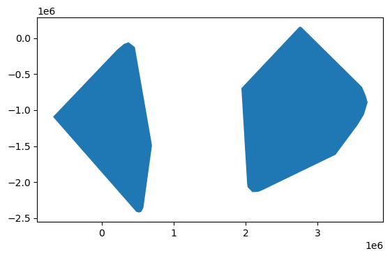

```python
#Lo graficamos
systems.convex_hull.plot()
```

```python
systems_hulls=systems.convex_hull.to_frame()
systems_hulls['system']=['Lena', 'Ob']
systems_hulls.rename(columns={0:'geometry'},inplace=True)
systems_hulls=systems_hulls.set_geometry('geometry')
systems_hulls.crs="EPSG:5940"
systems_hulls
```

|  | geometry | system |
| --- | --- | --- |
| 0 | POLYGON ((2093926.107 -2138584.299, 2026708.60... | Lena |
| 1 | POLYGON ((520296.618 -2422024.987, 481647.688 ... | Ob |

```python
#Como parate del ejercicio se crea la matriz
distanceMatrixKM_sysHull_air=systems_hulls.set_index('system').geometry.apply\
(lambda g: largeAirports.set_index('name').geometry.distance(g)/1000).\
sort_index(axis=0).sort_index(axis=1)

distanceMatrixKM_sysHull_air
```

| name system | Domodedovo International Airport | Gagarin International Airport | Kazan International Airport | Koltsovo Airport | Krasnoyarsk International Airport | Kurumoch International Airport | Lipetsk Air Base | Novosibirsk Tolmachevo Airport | Platov International Airport | Pulkovo Airport | Sheremetyevo International Airport | Sochi International Airport | Ufa International Airport | Vladivostok International Airport | Vnukovo International Airport | Zhukovsky International Airport |
| --- | --- | --- | --- | --- | --- | --- | --- | --- | --- | --- | --- | --- | --- | --- | --- | --- |
| Lena | 3766.482974 | 3736.285278 | 3225.831272 | 2586.124853 | 840.161394 | 3376.567655 | 3958.870588 | 1522.480341 | 4461.986391 | 3710.534353 | 3737.070580 | 4906.896096 | 3010.577975 | 1764.007075 | 3778.730258 | 3742.236297 |
| Ob | 1774.528190 | 1365.954481 | 1022.818275 | 236.594547 | 498.096617 | 1013.331380 | 1803.072357 | 0.000000 | 2069.622333 | 1971.111691 | 1777.892125 | 2410.072622 | 587.813297 | 3947.967254 | 1806.230339 | 1752.165499 |

```python
mins=distanceMatrixKM_sysHull_air.idxmin(axis="columns")
mins
```

```
system
Lena    Krasnoyarsk International Airport
Ob         Novosibirsk Tolmachevo Airport
dtype: object
```

```python
#Se grafican los puntos más cercanos y más lejanos
base=systems_hulls.explore()
largeAirports[largeAirports.name.isin(mins)].explore(m=base,color='red',marker_kwds=dict(radius=10))
largeAirports[~largeAirports.name.isin(mins)].explore(m=base,color='blue',marker_kwds=dict(radius=5))
```

Make this Notebook Trusted to load map: File -> Trust Notebook

[interactive chart not shown]

# EJERCICIO 04

## Distances using Buffers

1. Create a set of points and a set of lines
2. Get the buffer for the lines, select different values for the distance.
3. Keep the points that are within the buffer (as in point 2, you need to play with differn distances until you show something interesting.

```python
#Recordando de los ejercicios anteriores, se trabajara con el conjunto de puntos de aeropuertos y el conjunto de lineas seran los rios
distanceMatrixKM_riv_air
```

| name NAME | Domodedovo International Airport | Gagarin International Airport | Kazan International Airport | Koltsovo Airport | Krasnoyarsk International Airport | Kurumoch International Airport | Lipetsk Air Base | Novosibirsk Tolmachevo Airport | Platov International Airport | Pulkovo Airport | Sheremetyevo International Airport | Sochi International Airport | Ufa International Airport | Vladivostok International Airport | Vnukovo International Airport | Zhukovsky International Airport |
| --- | --- | --- | --- | --- | --- | --- | --- | --- | --- | --- | --- | --- | --- | --- | --- | --- |
| Aldan | 5027.998116 | 5035.582733 | 4521.215912 | 3888.328216 | 2035.497334 | 4678.017760 | 5239.325776 | 2714.557863 | 5758.133179 | 4900.381181 | 4993.193331 | 6208.416373 | 4314.150769 | 1764.007075 | 5036.508587 | 5003.912994 |
| Amur | 5431.181496 | 5251.089026 | 4786.906715 | 4042.003349 | 2012.928145 | 4878.976049 | 5567.274191 | 2702.477892 | 5983.865593 | 5475.414854 | 5413.813421 | 6364.114588 | 4464.454708 | 565.118977 | 5451.239297 | 5407.075949 |
| Angara | 3530.663620 | 3285.699633 | 2840.972611 | 2076.616665 | 242.622233 | 2913.869678 | 3630.849392 | 797.837026 | 4015.678265 | 3686.983821 | 3522.951504 | 4389.848106 | 2493.706304 | 2289.635425 | 3556.289970 | 3507.107226 |
| Dnieper | 264.285863 | 1002.785095 | 1034.955544 | 1781.774637 | 3791.541827 | 1163.796201 | 510.498177 | 3251.748751 | 1052.540379 | 519.588417 | 225.454698 | 1541.031266 | 1511.517710 | 7150.553889 | 216.667561 | 277.766385 |
| Don | 161.753368 | 328.568498 | 747.180126 | 1528.675097 | 3595.674022 | 694.896654 | 25.128259 | 2947.308884 | 34.429816 | 871.197816 | 237.104026 | 480.431753 | 1106.563629 | 7047.134704 | 198.735101 | 175.361673 |
| Irtysh | 2014.289618 | 1734.251864 | 1291.388906 | 524.606363 | 1171.242617 | 1362.128816 | 2083.741371 | 539.117240 | 2466.360561 | 2229.760741 | 2016.842105 | 2860.371157 | 948.595808 | 4675.531986 | 2045.223476 | 1991.676829 |
| Kama | 807.031244 | 500.448066 | 47.907842 | 323.246149 | 2269.211528 | 217.114367 | 797.249047 | 1742.535803 | 1218.567977 | 1342.360192 | 837.949229 | 1678.320029 | 218.631626 | 5669.372149 | 849.814621 | 789.120463 |
| Kolyma | 5547.749069 | 5709.264340 | 5181.481989 | 4650.039807 | 3181.395618 | 5377.012569 | 5813.871204 | 3793.112862 | 6395.208430 | 5245.323757 | 5499.203459 | 6883.269135 | 5057.244759 | 2463.722147 | 5545.611934 | 5524.872645 |
| Lena | 4330.983336 | 4115.449095 | 3661.810584 | 2905.787386 | 885.064391 | 3743.366440 | 4448.125502 | 1571.989455 | 4846.681754 | 4160.852636 | 4318.630548 | 5223.192217 | 3325.336224 | 2216.507997 | 4353.999594 | 4307.118387 |
| Neva | 666.349405 | 1371.285874 | 1183.785374 | 1761.120546 | 3586.907610 | 1398.847511 | 1020.755989 | 3126.023742 | 1639.913794 | 13.678333 | 590.192627 | 2144.277008 | 1624.245546 | 6812.140909 | 626.880060 | 658.760088 |
| Ob | 1878.027259 | 1827.625657 | 1309.291503 | 717.200900 | 531.356137 | 1475.811265 | 2043.755005 | 33.195292 | 2546.176363 | 1976.197075 | 1858.692319 | 3004.426166 | 1134.564018 | 3948.079082 | 1896.650115 | 1853.827258 |
| Pechora | 1409.739657 | 1415.149178 | 887.482871 | 628.628301 | 2098.372697 | 1094.741925 | 1585.329618 | 1655.776457 | 2114.069953 | 1355.004335 | 1390.388313 | 2590.774517 | 867.939130 | 5423.408263 | 1428.237552 | 1385.527289 |
| Suir | 669.663606 | 1299.348913 | 1035.789826 | 1565.268054 | 3365.119672 | 1272.652359 | 1023.069918 | 2913.958325 | 1664.566373 | 183.811979 | 597.213951 | 2180.681681 | 1454.489353 | 6570.493214 | 641.842206 | 655.225054 |
| Tobol | 1831.659228 | 1365.954481 | 1050.167533 | 349.110969 | 1577.608083 | 1013.331380 | 1805.744965 | 1016.180003 | 2069.622333 | 2267.908535 | 1855.209076 | 2410.072622 | 589.320016 | 5046.116594 | 1872.061613 | 1812.395401 |
| Ural | 1167.659755 | 489.627221 | 555.453694 | 254.877223 | 2239.531487 | 303.386233 | 1002.951282 | 1600.884165 | 1142.886401 | 1810.382399 | 1220.601122 | 1486.195381 | 248.624026 | 5737.430359 | 1216.546199 | 1156.868867 |
| Vilyuy | 3766.482974 | 3736.285278 | 3225.831272 | 2586.124853 | 1328.007873 | 3376.567655 | 3958.870588 | 1777.455127 | 4461.986391 | 3710.534353 | 3737.070580 | 4906.896096 | 3010.577975 | 2533.966189 | 3778.730258 | 3742.236297 |
| Volga | 171.508841 | 15.185173 | 0.123628 | 780.777353 | 2865.493904 | 3.061834 | 527.431698 | 2269.127499 | 430.721740 | 337.218613 | 95.334368 | 792.497897 | 423.712508 | 6316.859874 | 135.278269 | 164.666019 |
| Yenisey | 2842.135587 | 2926.968183 | 2411.513501 | 1747.352368 | 18.449557 | 2560.099507 | 3076.038096 | 597.542697 | 3634.515070 | 2709.242947 | 2803.462053 | 4085.184907 | 2175.663038 | 3006.567657 | 2847.747346 | 2818.291720 |

```python
#Se obtiene el buffer para las líneas
bufferAroundOb=rivers[rivers.NAME=='Ob'].buffer(distance = minMts)
bufferAsBase=bufferAroundOb.explore(color='red')
rivers[rivers.NAME=='Ob'].explore(m=bufferAsBase,color='blue',style_kwds={'weight':0.5})
```

Make this Notebook Trusted to load map: File -> Trust Notebook

[interactive chart not shown]

```python
#Observamos que  estan todos los pequeños aeropuertos y algunos caen dentro del buffer
small_airports=airports[airports['kind']=='small_airport']

# graficamos
rivers[rivers.NAME=='Ob'].explore(m=bufferAsBase,color='blue',style_kwds={'weight':0.5})
small_airports.explore(m=bufferAsBase,color='black')
```

Make this Notebook Trusted to load map: File -> Trust Notebook

[interactive chart not shown]

```python
#rios dentro del buffer
riversWithinBuffer=small_airports.clip(mask=bufferAroundOb)

riversWithinBuffer
```

|  | name | kind | latitude_deg | longitude_deg | elevation_ft | region_name | municipality | geometry |
| --- | --- | --- | --- | --- | --- | --- | --- | --- |
| 948 | Ust-Koksa Airport | small_airport | 50.264711 | 85.713489 | 3235.0 | Altai Republic | Ust-Koksa Airport | POINT (483900.668 -2332569.708) |
| 549 | Barantal Aerodrome | small_airport | 51.446630 | 85.988850 | 1598.0 | Altai Republic | Elekmonar | POINT (552688.245 -2200642.806) |
| 526 | Karasuk Vertodrome-Aerodrome | small_airport | 51.561840 | 85.918510 | 1234.0 | Altai Republic | Cheposh | POINT (552204.681 -2185355.846) |
| 708 | Manzherok Airport | small_airport | 51.825260 | 85.805930 | 1293.0 | Altai Republic | Manzherok | POINT (554715.363 -2151675.629) |
| 488 | Lesnoy Airfield | small_airport | 53.251722 | 83.954945 | NaN | Altai Krai | Barnaul | POINT (484535.522 -1938659.687) |
| 176 | Iskitim Airfield | small_airport | 54.600000 | 83.300000 | NaN | Novgorod Oblast | Iskitim | POINT (500609.063 -1767803.043) |
| 498 | Yuzhnaya Airfield | small_airport | 54.654719 | 83.078699 | NaN | Novosibirsk Oblast | Berdsk | POINT (488557.341 -1755796.413) |
| 497 | Berdsk Airfield | small_airport | 54.735001 | 83.095001 | NaN | Novosibirsk Oblast | Berdsk | POINT (493275.249 -1747150.857) |
| 767 | ObGES Airfield | small_airport | 54.874001 | 82.983002 | NaN | Novosibirsk Oblast | Novosibirsk | POINT (492298.603 -1728506.767) |
| 143 | Gorodskoy Aeroport Airfield | small_airport | 55.095730 | 82.909450 | 564.0 | Novosibirsk Oblast | Novosibirsk | POINT (497657.636 -1701574.386) |
| 768 | Mochische Airfield | small_airport | 55.168999 | 83.142998 | 718.0 | Novosibirsk Oblast | Novosibirsk | POINT (516074.133 -1699401.283) |
| 996 | Yurt-Ora Airstrip | small_airport | 55.450175 | 82.916468 | NaN | Novosibirsk Oblast | Yurt-Ora | POINT (514297.334 -1661863.527) |
| 912 | Beryozkino Airfield | small_airport | 56.502640 | 84.686575 | 394.0 | Tomsk Oblast | Tomsk | POINT (672336.449 -1586558.051) |
| 639 | Kolpashevo Airport | small_airport | 58.325298 | 82.932503 | 243.0 | Tomsk Oblast | Kolpashevo | POINT (645450.369 -1341289.849) |
| 797 | Parabel Airport | small_airport | 58.707480 | 81.464330 | 177.0 | Tomsk Oblast | Parabel | POINT (578523.968 -1263613.304) |
| 602 | Kargasok Airport | small_airport | 59.061858 | 80.823204 | 194.0 | Tomsk Oblast | Kargasok | POINT (559409.347 -1208934.678) |
| 458 | Aleksandrovskoye Airport | small_airport | 60.445636 | 77.837069 | NaN | Tomsk Oblast | Aleksandrovskoye | POINT (469261.163 -983241.537) |

```python
#Solo nos quedamos con los aeropuertos que caen dentro del buffer
bufferAsBase=bufferAroundOb.explore(color='red')
rivers[rivers.NAME=='Ob'].explore(m=bufferAsBase,color='blue',style_kwds={'weight':0.5})
riversWithinBuffer.explore(m=bufferAsBase,color='black')
```

Make this Notebook Trusted to load map: File -> Trust Notebook

[interactive chart not shown]

# EJERCICIO 05

## Using data from spatial objects

1. Get a polygons map of the lowest administrative unit possible.
2. Get a table of variables for those units. At least 3 numerical variables.
3. Preprocess both tables and get them ready for merging.
4. Do the merging, making the changes needed so that you keep the most columns.

# EJERCICIO 06

## Exploring one variable

1. Choose a numeric variable from your merged data.
2. Decide which is the best classification scheme for that variable.
3. Make a map for the best scheme.
4. Make a histogram for the best scheme.

# EJERCICIO 07

## Neighborhood

Compute the neighbors of the capital of your country. Plot the results for each of the options.

# EJERCICIO 08

## Spatial correlation

1. Compute the Moran's coefficient for all your numeric variables.
2. Make a scatter plot for each variable.

# EJERCICIO 09

## Local Spatial Correlation

1. Compute the Local Moran for the variables in your data that have significant spatial correlation.
2. Create a new column for each of those variables, with a label ('0 no_sig', '1 hotSpot', '2 coldOutlier', '3 coldSpot', '4 hotOutlier').
3. Prepare a map for each of the variables analyzed, showing the spots and outliers.